# Problem Set 06: Control flow and functions

# Instructions

Create a Quarto markdown document and answer the questions below using code blocks that generate the correct outputs. We encourage you to include explanatory text in your markdown document, however **each of your solutions should show how to generate the answer using R code**.

Write “robust” solutions wherever possible. A good rule of thumb for judging whether your solution is appropriately “robust” is to ask yourself “If I added additional observations or variables to this data set, or if the order of variables changed, would my code still compute the right solution?”

Make sure your markdown is nicely formatted – use headers, bullets, numbering, etc so that the structure of the document is clear.

Make sure to “Render” your document before submission to confirm that all code blocks and formatting is as you expect.

When completed, title your markdown file as follows (replace `XX` with the assignment number, e.g. `01`, `02`, etc):

- `netid-assignment_XX-Fall2023.qmd`

Submit both your markdown file and the generated HTML document via the Assignments submission section on Sakai.

# Problems

In the following problems you’re going to use simple functions and for loops to simulate [sampling distributions of statistics](https://en.wikipedia.org/wiki/Sampling_distribution) like the mean and the standard deviation. If you didn’t fully grok what a sampling distribution was when you took intro stats, hopefully this exercise will make that concept a little more concrete.

## Problem 1

The function `rnorm(n, mean = 0, sd = 1)` draws `n` random observations from a normal distribution with the specified mean and standard deviation (0 and 1 by default). For example, the code below draws 5 observations from a normal distribution with mean = 10, sd = 2:

```r
rnorm(5, mean = 10, sd = 2)
```

[output not shown]

```r
sample.mean.of.normal <- function(n, mean = 0, sd = 1) {
  # your code here
}
```

- Show some tests of your function in the code block below.

```r
# Write tests of your implementation of sample.mean.of.normal
```

- If you call `sample.mean.of.normal` repeatedly with the same inputs, do you get the same or different results? Is that surprising or expected behavior? Explain.

## Problem 2

In this problem you’re going to simulate the sampling distribution of the mean.

```r
# for loop that calls sample.mean.of.normal 1000 times,
# n = 5, mean = 0, sd = 1
```

- Repeat the above but for with the parameters `n = 50, mean = 0, sd = 1`. As before, store the sample means in a vector.

```r
# for loop that calls sample.mean.of.normal 1000 times,
# with n = 50, mean = 0, sd = 1
```

- Create a data frame with two columns, `means_5` and `means_50`, from the vectors of sample means

```r
# create your data frame here
```

- Use the data frame you created to generate faceted histograms comparing the distribution of sample means for samples of size 5 and 50. `pivot_longer` will be useful in this task. Your final figure should look something like this.

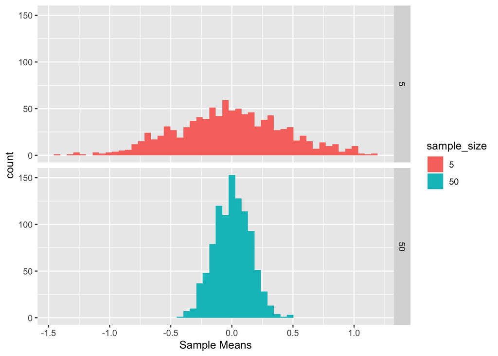

- Calculate the mean and standard deviation of the distribution of means for samples of size 5 and 50. How does the mean of means compare between samples of size 5 and 50? How does the standard deviation of means (the standard error of the mean!) compare between samples of size 5 and 50?

## Problem 3

- Write a function `sample.statistic.of.normal` that takes four arguments `statistic` (a character), `n`, `mean`, and `sd`. The last three arguments are the same as defined previously.

  If `statistic` is the string “mean” your code should return the mean of the sample. If `statistic` is the string “sd” your code should return the standard deviation of the statistic. If statistic is “iqr” your code should return the interquartile range (an alternate measure of the spread of a distribution; see help under `IQR`)

  Your function should use `if-else` statements.

```r
sample.statistic.of.normal <- function(statistic, n, mean = 0, sd = 1) {
  # your code here
}
```

- Using your `sample.statistic.of.normal` function, use a for-loop to generate 1000 samples of size 20 for both the standard deviation and the IQR and plot the sampling distributions of each of these statistics.